# Customers Churn Prediction

# 4. Hypothesis Generation

What's the best metric for comparing models? Since the classes are unbalanced, model accuracy is not enough (correct guesses / total guesses). If we were naively to predict all customers to not churn, we would have ~85% accuracy. Knowing this, we should use either precision or recall.

Because losing a customer is more costly than whatever measures are taken to prevent a customer from leaving, minimizing false negatives (saying a customer wouldn't churn and they do), is the number to minimize. Thus, recall will be our primary model metric, while still considering precision.

The real goal behind reducing customers churn is to reduce the loss of churn. In other words, we want to reduce the cost of churning customers.

The predictive models that we are going to build will not be judged on their accuracy but on their ability to reduce churn cost per customer.  
Let's first introduce the confusion matrix of the cost relative to customers churn.

- True Positive (TP) as a customer that is predicted to churn and actually churns
- True Negative (TN) as a customer that is predicted to not churn and that doesn't churn
- False Positive (FP) as a customer that is predicted to churn and actually doesn't churn
- False Negative (FN) as a customer that is predicted to not churn but actually churns

Suppose that the Life Time Value (LTV) of a customer is approximately \$1,000 (3 years at ~\$30/month subscription plan). This means that each customer that quit the company means \$1,000 loss for the company. When a customer is detected as churning, we offer him an incentive of \$100, to make him stay longer with the operator. This is a loss for the company of \$100 that is less dramatic than loosing \$1,000.  
Not all customers that are receiving the \$100 offer will accept it. We suppose to have a 50% chance the customer accept the offer, which in term of mean loss, is \$550 per customer that is detected to churn and decide to stay 0.5 x \$1,000 + 0.5 x \$100.

Here I summarize the churn costs in a confusion matrix way:

- TP costs the company \$550
- TN costs the company \$0
- FP costs the company \$100
- FN costs the company \$1,000

Our ultimate predictor must minimize the total churn cost given the costs list below. For calculation convenience, we will devide the total cost by the number of customers and minimize the churn cost per customer (CCpC).

## Helper Functions

- Following function calculates the CCpC given an estimator, the input/output values, and returns the minimum churn cost per customer, and the corresponding probability threshold:

```python
from sklearn.metrics import confusion_matrix
from sklearn.grid_search import GridSearchCV

# Confusion matrix cost
cmc = np.array([[0, 1000], [100, 550]])

# Get the confusion matrix as costs
def confusion_matrix_cost(Y_pred, Y_obs):
    return confusion_matrix(Y_pred, Y_obs, labels = [0, 1]) * cmc

# Calculate the total Churn Cost per Customer given Y predicted and observed
def calculate_ccpc(Y_pred, Y_obs):
    return np.sum(confusion_matrix_cost(Y_pred, Y_obs)) / float(len(Y_obs))

# Calculate accuracy by looking at the mean of correct predictions
# Y observed and predicted can be given in any order
def calculate_accuracy(Y_1, Y_2):
    return np.mean(np.logical_not(np.logical_xor(Y_1, Y_2)).astype(int))

# Predict churn given a probabilistic threshold t
def predict_with_threshold(model, X, t=0.5):
    return (model.predict_proba(X)[:,1] >= t).astype(int)

# Get the min churn cost per customer, and the associated probability threshold
def churn_cost_per_customer_and_threshold(model, X, Y):
    min_cost, optimal_t = np.max(cmc), 0

    for t in np.arange(0, 1.01, 0.01):
        Y_predicted = predict_with_threshold(model, X, t)
        ccpc = calculate_ccpc(Y_predicted, Y)

        if ccpc < min_cost:
            min_cost = ccpc
            optimal_t = t

    return min_cost, optimal_t

# Only the churn cost per customer
def churn_cost_per_customer(model, X, Y):
    return churn_cost_per_customer_and_threshold(model, X, Y)[0]

# Scorer used in GridSearchCV that minimizes the churn_cost_per_customer (=> maximize the inverse)
def scorer_based_on_churn_cost_per_customer(model, X, Y):
    return 1.0 / churn_cost_per_customer(model, X, Y)

# POC plot function
import matplotlib.pyplot as plt
def plot_roc(scores, max_score, max_score_threshold):
    # plot
    thresholds = np.arange(0, 1.01, 0.01)
    plt.plot(thresholds, scores, label = 'Evolution of score')

    # plot the cross pt
    plt.plot([0, max_score_threshold], [max_score, max_score], color = 'r', alpha = 0.2, label = 'Max score')
    plt.plot([max_score_threshold, max_score_threshold], [0, max_score], 'r--', alpha = 0.2)
    plt.plot([max_score_threshold], [max_score], 'bo')

    # helper box
    plt.legend()
    plt.ylim(0, 1)
    plt.xlabel('Probability Threshold')
    plt.ylabel('Model accuracy')
    plt.title('Evolution of model accuracy depending on probability threshold')
    plt.show()
```

# 5. Build Model

## Base Model

To better judge on the churn costs per customer, let's consider two extreme cases: The first one is about a dummy estimator that predicts all customers are churning, and an other one with no customers churning.

```python
ccpc_all_churn = calculate_ccpc(np.ones(len(Y_test)), Y_test)
ccpc_no_churn = calculate_ccpc(np.zeros(len(Y_test)), Y_test)

print("Churn cost per customer All churn = " + str(ccpc_all_churn))
print("Churn cost per customer No churn = " + str(ccpc_no_churn))
```

```
Churn cost per customer All churn = 165.442278861
Churn cost per customer No churn = 145.427286357
```

## Logistic Regression - Normal

```python
from sklearn.linear_model import LogisticRegression

lr_cf = LogisticRegression()
lr_gs = GridSearchCV(lr_cf, param_grid={'C': [10**i for i in range(-3, 3)], 'penalty': ['l1', 'l2']}, cv=5)
lr_gs.fit(X_train, Y_train)
lr_est = lr_gs.best_estimator_

print("Using LR params %s produce the best model accuracy: %f" % (lr_gs.best_params_, lr_gs.best_score_))
print("Accuracy on training data = %f" % lr_est.score(X_train, Y_train))
print("Accuracy on test data = %f" % lr_est.score(X_test, Y_test))
```

```
Using LR params {'penalty': 'l1', 'C': 1} produce the best model accuracy: 0.864591
Accuracy on training data = 0.870218
Accuracy on test data = 0.859070
```

```
Max accuracy occurs at probability threshold 0.53, with score of 0.87
Churn Cost Per Costomer 134.78
```

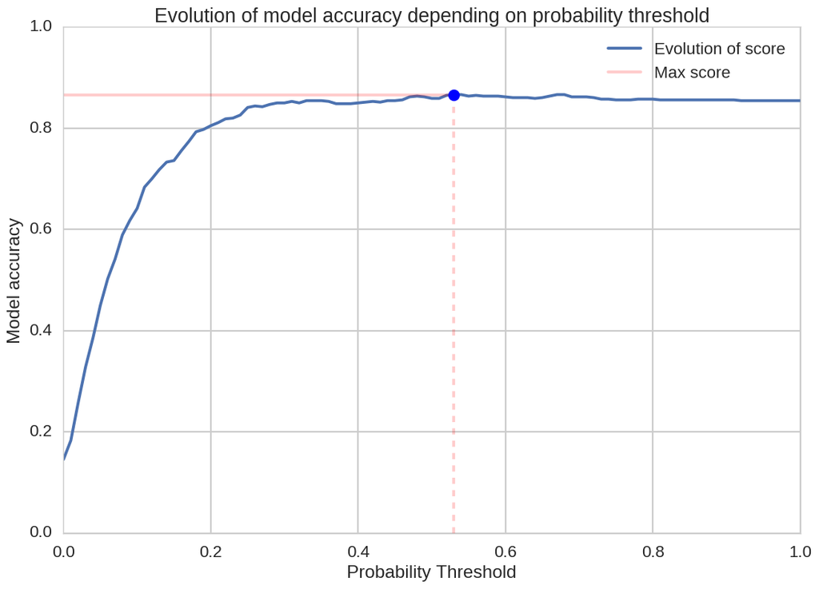

```python
# The prob. thresholds
thresholds = np.arange(0, 1.01, 0.01)
scores = []

for t in thresholds:
    Y_predicted = predict_with_threshold(lr_est, X_test, t)
    right_predictions = (Y_predicted == Y_test.values)
    scores.append(np.mean(right_predictions.astype(int)))

# Getting the threshold that maximizes the score
max_score, max_score_threshold = np.max(scores), thresholds[np.argmax(scores)] # argmax returnx idx in scores
print("Max accuracy occurs at probability threshold %0.2f, with score of %0.2f" % (max_score_threshold, max_score))
print("Churn Cost Per Costomer %0.2f" % calculate_ccpc(predict_with_threshold(lr_est, X_test, max_score_threshold), Y_test))

# plot roc
plot_roc(scores, max_score, max_score_threshold)
```

# Use the churn cost per customer to find the best estimation.

## Logistic Regression - using churn cost per customer

```python
lr_gs = GridSearchCV(lr_cf,
                     param_grid={'C': [10**i for i in range(-3, 3)], 'penalty': ['l1', 'l2']},
                     cv=5,
                     scoring=scorer_based_on_churn_cost_per_customer)
lr_gs.fit(X_train, Y_train)
lr_est = lr_gs.best_estimator_
print("Using LR params %s help get the minimum CCpC" % lr_gs.best_params_)
```

```
Using LR params {'penalty': 'l1', 'C': 1} help get the minimum CCpC
```

```
Max accuracy occurs at probability threshold 0.53, with score of 0.87
Churn Cost Per Costomer 134.78
```

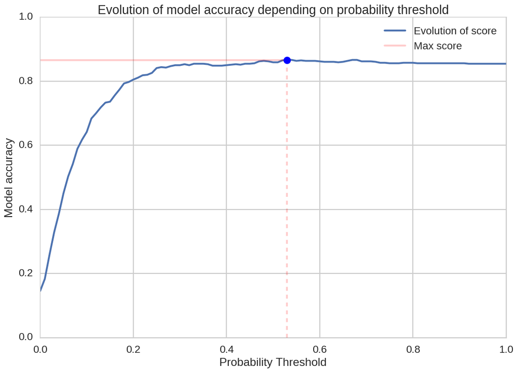

```python
# The prob. thresholds
thresholds = np.arange(0, 1.01, 0.01)
scores = []

for t in thresholds:
    Y_predicted = predict_with_threshold(lr_est, X_test, t)
    right_predictions = (Y_predicted == Y_test.values)
    scores.append(np.mean(right_predictions.astype(int)))

# Getting the threshold that maximizes the score
max_score, max_score_threshold = np.max(scores), thresholds[np.argmax(scores)] # argmax returnx idx in scores
print("Max accuracy occurs at probability threshold %0.2f, with score of %0.2f" % (max_score_threshold, max_score))
print("Churn Cost Per Costomer %0.2f" % calculate_ccpc(predict_with_threshold(lr_est, X_test, max_score_threshold), Y_test))

# plot roc
plot_roc(scores, max_score, max_score_threshold)
```

## Randome Forest

```python
from sklearn.ensemble import RandomForestClassifier

rf_cf = RandomForestClassifier(n_jobs=-1)
rf_gs = GridSearchCV(rf_cf, param_grid={'n_estimators': [100, 500]},
                     cv=5,
                     scoring=scorer_based_on_churn_cost_per_customer)
rf_gs.fit(X_train, Y_train)
rf_est = rf_gs.best_estimator_

print "Using RF params %s produce the best model accuracy: %f" % (rf_gs.best_params_, rf_gs.best_score_)
print "Accuracy on training data = %f" % rf_est.score(X_train, Y_train)
print "Accuracy on test data = %f" % rf_est.score(X_test, Y_test)
```

```
Using RF params {'n_estimators': 500} produce the best model accuracy: 0.010669
Accuracy on training data = 1.000000
Accuracy on test data = 0.941529
```

```
Max accuracy occurs at probability threshold 0.40, with score of 0.95
Churn Cost Per Costomer 96.18
```

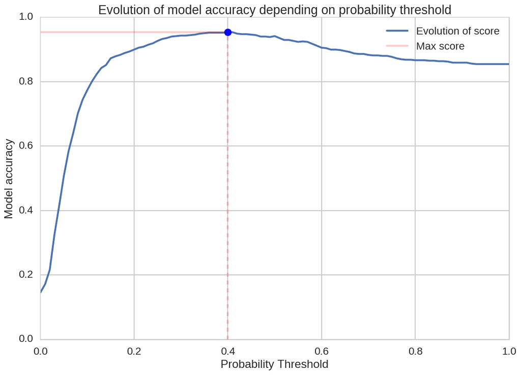

```python
# The prob. thresholds
thresholds = np.arange(0, 1.01, 0.01)
scores = []

for t in thresholds:
    Y_predicted = predict_with_threshold(rf_est, X_test, t)
    right_predictions = (Y_predicted == Y_test.values)
    scores.append(np.mean(right_predictions.astype(int)))

# Getting the threshold that maximizes the score
max_score, max_score_threshold = np.max(scores), thresholds[np.argmax(scores)] # argmax returnx idx in scores
print("Max accuracy occurs at probability threshold %0.2f, with score of %0.2f" % (max_score_threshold, max_score))
print("Churn Cost Per Costomer %0.2f" % calculate_ccpc(predict_with_threshold(rf_est, X_test, max_score_threshold), Y_test))

# plot roc
plot_roc(scores, max_score, max_score_threshold)
```

## Naive Bayes

```python
from sklearn.naive_bayes import GaussianNB

nb_cf = GaussianNB()
nb_gs = GridSearchCV(nb_cf,
                     param_grid={},
                     cv=5,
                     scoring=scorer_based_on_churn_cost_per_customer)
nb_gs.fit(X_train, Y_train)
nb_est = nb_gs.best_estimator_

print "Accuracy on training data = %f" % nb_est.score(X_train, Y_train)
print "Accuracy on test data = %f" % nb_est.score(X_test, Y_test)
```

```
Accuracy on training data = 0.614779
Accuracy on test data = 0.578711
```

```
Max accuracy occurs at probability threshold 1.00, with score of 0.85
Churn Cost Per Costomer 145.58
```

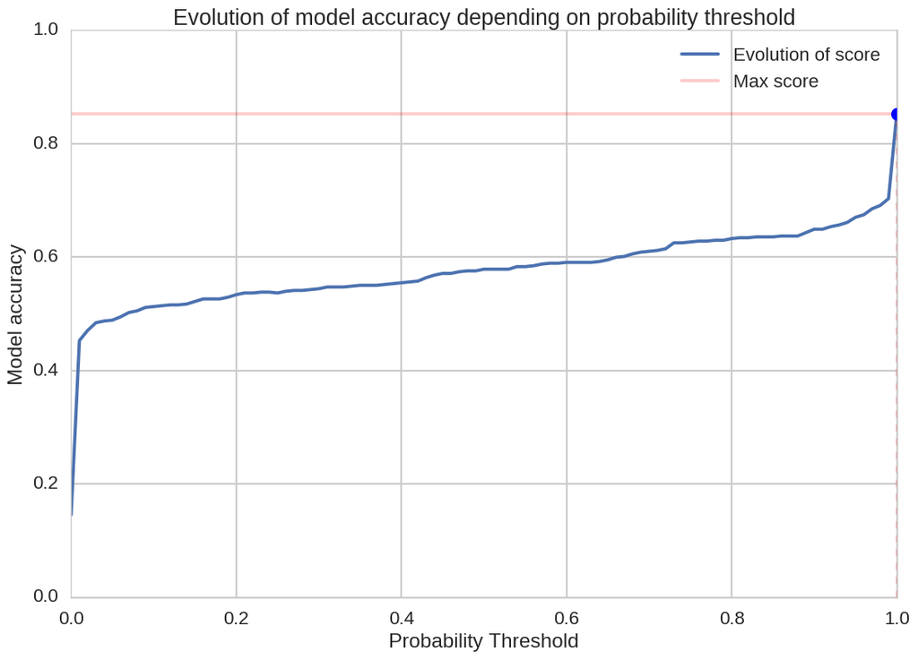

```python
# The prob. thresholds
thresholds = np.arange(0, 1.01, 0.01)
scores = []

for t in thresholds:
    Y_predicted = predict_with_threshold(nb_est, X_test, t)
    right_predictions = (Y_predicted == Y_test.values)
    scores.append(np.mean(right_predictions.astype(int)))

# Getting the threshold that maximizes the score
max_score, max_score_threshold = np.max(scores), thresholds[np.argmax(scores)] # argmax returnx idx in scores
print("Max accuracy occurs at probability threshold %0.2f, with score of %0.2f" % (max_score_threshold, max_score))
print("Churn Cost Per Costomer %0.2f" % calculate_ccpc(predict_with_threshold(nb_est, X_test, max_score_threshold), Y_test))

# plot roc
plot_roc(scores, max_score, max_score_threshold)
```

# 6. Visualizing churn cost per customer of the three estimators

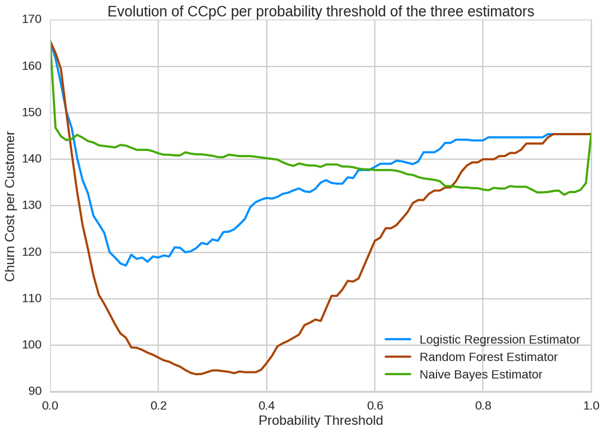

```python
thresholds = np.arange(0, 1.01, 0.01)

lr_ccpc = [calculate_ccpc(predict_with_threshold(lr_est, X_test, t), Y_test) for t in thresholds]
rf_ccpc = [calculate_ccpc(predict_with_threshold(rf_est, X_test, t), Y_test) for t in thresholds]
nb_ccpc = [calculate_ccpc(predict_with_threshold(nb_est, X_test, t), Y_test) for t in thresholds]

plt.plot(thresholds, lr_ccpc, color = '#0090ff', label = "Logistic Regression Estimator")
plt.plot(thresholds, rf_ccpc, color = '#aa4400', label = "Random Forest Estimator")
plt.plot(thresholds, nb_ccpc, color = '#44aa00', label = "Naive Bayes Estimator")
plt.legend(loc = 'lower right')
plt.xlabel('Probability Threshold')
plt.ylabel('Churn Cost per Customer')
plt.title('Evolution of CCpC per probability threshold of the three estimators')
plt.show()
```

```python
print "Min CCpC for RF estimator is $%3.2f" % np.min(rf_ccpc)
print "Corresponding probability threshold is %0.2f" % thresholds[np.argmin(rf_ccpc)]
```

```
Min CCpC for RF estimator is $93.78
Corresponding probability threshold is 0.27
```

# 7. Conclusion